# Chapter 8 HW

Vivian Kong

11/21/2016

## 8.2 Baby Weights, Part II

#### a)

$$y=120.07 - 1.93 x_{parity}$$

#### b)

slope is -1.93 which meas 1 parity increasing will decrease the baby’s weigh by 1.93 oz. The first baby is 118.14 oz.

#### c)

since p-value is 0.1052 which is not a significant relationship between the average birth weigh and parity.

## 8.4 Absenteeism

#### a)

$$y = 18.93 - 9.11 x_{eth} + 3.10 x_{sex} + 2.15 x_{lrn}$$

#### b)

The slope of eth means that all else being the same, when eth increase by 1, it will decrease the y by 9.11 days. The slope of sex means that all else being the same, when the subject is male, y will increase by 3.10 days. The slope of lrn means that all else being the same, when the subject is a slow learner, y will increase by 2.15 days.

#### c)

```r
eth <- 0
sex <- 1
lrn <- 1
actualDayMissed <- 2

absDaysPred <- 18.93 - 9.11 * eth + 3.1 * sex + 2.15 * lrn
absDaysPred
```

```
## [1] 24.18
```

```r
residual <- actualDayMissed - absDaysPred
residual
```

```
## [1] -22.18
```

The residual is -22.18 days.

#### d)

```r
n <- 146
k <- 3
varRes <- 240.57
varOut <- 264.17

r2 <- 1- (varRes/ varOut)
r2
```

```
## [1] 0.08933641
```

```r
adjustedr2 <- 1- (1 - r2) * ((n-1) / (n-k-1))
adjustedr2
```

```
## [1] 0.07009704
```

## 8.8 Absenteeism

In this case, we will remove the ethnicity first.

## 8.16 Challenger disaster

#### a)

When the temperature is less than 66, there is more damaged O-rings.

#### b)

The key components are the Intercept and the Temperature values. Z-value and P-value help us distinguish the significant levels.

#### c)

$$\log_e(\frac{p_i}{1-p_i}) = 11.6630 - 0.2162 x_{temp}$$

#### d)

Since the p-value is very close to 0, it indicates that the O-ring failure is strongly correlated to temperature.

## 8.18 Challenger disaster, Part II

#### a)

```r
temp <- 51
p <- exp(11.6630-(0.2162 * temp)) / (1+exp(11.6630- (0.2162 * temp)))
p
```

```
## [1] 0.6540297
```

```r
temp1<- 53
p2 <- exp(11.6630-(0.2162 * temp1)) / (1+exp(11.6630- (0.2162 * temp1)))
p2
```

```
## [1] 0.5509228
```

```r
temp2 <- 55
p3 <-exp(11.6630-(0.2162 * temp2)) / (1+exp(11.6630- (0.2162 * temp2)))
p3
```

```
## [1] 0.4432456
```

#### b)

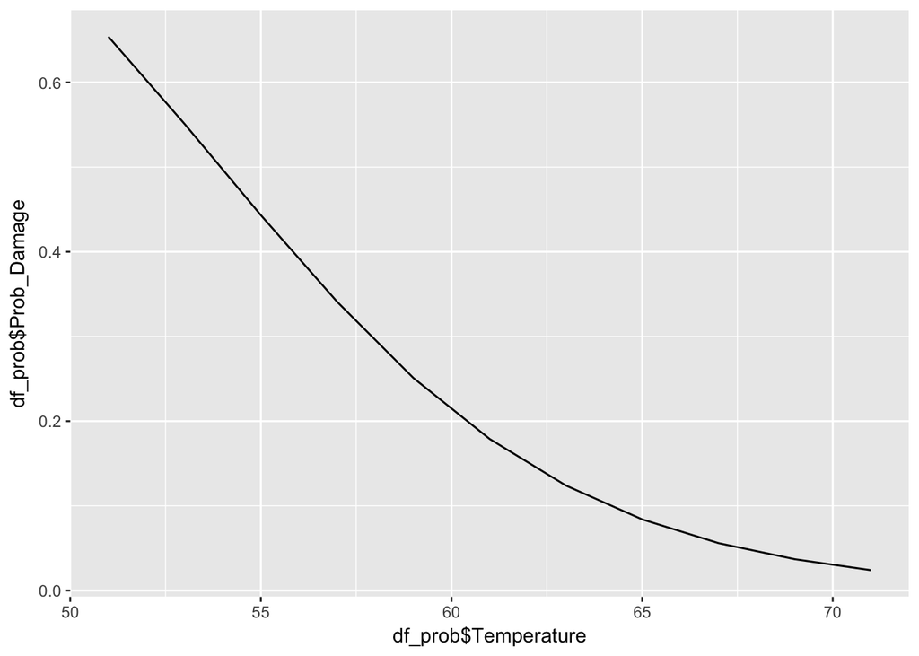

```r
library(ggplot2)
temps <- seq(51, 71, by=2)
probs <- c(p, p2, p3, 0.341, 0.251, 0.179, 0.124, 0.084, 0.056, 0.037, 0.024)
df_prob <- data.frame(Temperature = temps, Prob_Damage = probs)
g1 <- ggplot(df_prob) + geom_line(aes(x=df_prob$Temperature, y=df_prob$Prob_Damage))
g1
```